# Speed Dating Prediction

Group 37, Xin Qu, NetID: xinq2; Biruo Zhao, NetID: biruoz2; Chen Ling, NetID: ling10; Luwei Zhang, NetID: luwei2

## Introduction

This dataset was compiled by Columbia Business School professors Ray Fisman and Sheena Iyengar for their paper [Gender Differences in Mate Selection: Evidence From a Speed Dating Experiment](http://faculty.chicagobooth.edu/emir.kamenica/documents/genderDifferences.pdf). The dataset is available on [Kaggle](https://www.kaggle.com/annavictoria/speed-dating-experiment/home).

Data was gathered from participants in experimental speed dating events from 2002-2004. During the events, the attendees would have a four minute “first date” with every other participant of the opposite sex. At the end of their four minutes, participants were asked if they would like to see their date again. They were also asked to rate their date on six attributes: Attractiveness, Sincerity, Intelligence, Fun, Ambition, and Shared Interests.

The dataset also includes questionnaire data gathered from participants at different points in the process. These fields include: demographics, dating habits, self-perception across key attributes, beliefs on what others find valuable in a mate, and lifestyle information. See the attached Speed Dating Data Key document for details.

**The aim of this project is two-fold: explanation and prediction**. In this project, we want to explore what people are looking for in their speed dating partners (attractive, sincere, intelligent, fun, ambitious or shared interests/hobbies), what it takes to get high scores from a potential partner and if any other factors (gender, age, same race etc.) influence peoples’ decisions.

There are 8378 observations with 195 variables in the dataset. **The response we’re focusing on is `like_o` which is the rating of how much a participant likes his/her speed-dating partner** and we believe this numerical value is a good measurement of a person’s overall success in the speed dating experiment.

- `like_o`: rate of like of speed-dating partner

**And the predictors under consideration include:**

- `age_o`: age of speed-dating partner
- `attr_o`: rate of attractiveness of speed-dating partner
- `sinc_o`: rate of sincerity of speed-dating partner
- `intel_o`: rate of intelligence of speed-dating partner
- `fun_o`: rate of fun of speed-dating partner
- `amb_o`: rate of ambition of speed-dating partner
- `shar_o`: rate of shared interests of speed-dating partner
- `gender`: gender of speed-dating partner, 0 stands for male and 1 stands for female
- `samerace`: whether participant and partner were the same race. 0 stands for no and 1 stands for yes
- `dec_o`: decision to see partner again, 0 stands for no and 1 stands for yes
- `match`: a match occurs when both participant and partner check “yes” for decision

Our purpose is to build a “best” model to explain and predict the relationship between the response and the predictors. We are looking for a linear model that is small and interpretable, but still fits the data well. Since what we have here in the speed dating experiment is observational data and with observational data, we can only detect associations.

For the purpose of explanation, our project will utilize the following concepts and strategies:

- Multiple linear regression
- Dummy variables
- Assumption diagnostics
- Collinearity
- Outlier diagnostics
- Interaction
- Transformations
- Polynomial regression
- Model selection

For the purpose of prediction, this project will also apply the following concepts and strategies:

- Test-Train Split
- Residual diagnostics
- Outlier diagnostics
- Model selection

The `library` used in this project:

- library(readr)
- library(lmtest)
- library(faraway)
- library(MASS)
- library(knitr)

## Methods

```r
library(readr)
library(lmtest)
library(faraway)
library(MASS)
library(knitr)
```

### 1. Load and clean the data by removing irrelevant variables

```r
# coerce categorical variable to be factor variables
rawdata = read.csv('Speed Dating Data.csv')
rawdata$gender = as.factor(rawdata$gender)
rawdata$samerace = as.factor(rawdata$samerace)
rawdata$dec_o = as.factor(rawdata$dec_o)
rawdata$match = as.factor(rawdata$match)
```

```r
selected_data = subset(rawdata, select =
                     c("age_o","attr_o","sinc_o","intel_o","fun_o","amb_o","shar_o","like_o","gender","samerace","match","dec_o"))
selected_data = selected_data[complete.cases(selected_data), ] # find complete data
```

### 2. Split data into `train` and `test` two subsets

The `train` subset contains 4850 observations and the `test` dataset contains the rest.

```r
set.seed(1)
train_idx  = sample(nrow(selected_data), size = nrow(selected_data)*0.7)
train_data = selected_data[train_idx, ]
test_data = selected_data[-train_idx, ]
```

### 3. Model Building

Useful tests or concepts used for model building:

- Fitted versus Residuals Plot
- Q-Q Plot
- Breusch-Pagan Test
- Shapiro-Wilk Test
- Parametric approach
- Leverage
- Adjusted $R^2$
- Average Percentage Error
- AIC
- BIC
- LOOCV RMSE

```r
# Fitted versus Residuals Plot
plot_fitted_resid = function(model, pointcol = "dodgerblue", linecol = "darkorange") {
  plot(fitted(model), resid(model),
       col = pointcol, pch = 20, cex = 1.5,
       xlab = "Fitted", ylab = "Residuals")
  abline(h = 0, col = linecol, lwd = 2)
}
# Q-Q plot
plot_qq = function(model, pointcol = "dodgerblue", linecol = "darkorange") {
  qqnorm(resid(model), col = pointcol, pch = 20, cex = 1.5)
  qqline(resid(model), col = linecol, lwd = 2)
}
# bptest
get_bp_decision = function(model, alpha) {
  decide = unname(bptest(model)$p.value < alpha)
  ifelse(decide, "Reject", "Fail to Reject")
}
# swtest
get_sw_decision = function(model, alpha) {
  decide = unname(shapiro.test(resid(model))$p.value < alpha)
  ifelse(decide, "Reject", "Fail to Reject")
}

get_num_params = function(model) {
  length(coef(model))
}

get_loocv_rmse = function(model) {
  sqrt(mean((resid(model) / (1 - hatvalues(model))) ^ 2))
}

get_adj_r2 = function(model) {
  summary(model)$adj.r.squared
}
# average percentage error
get_prec_err = function(predicted, actual) {
  mean(abs(actual - predicted) / predicted)
}
```

#### 3.1 Check collinearity of the data:

```r
#pairs(train_data, col = "dodgerblue")
cor(train_data[,2:7])
```

```
##            attr_o    sinc_o   intel_o     fun_o     amb_o    shar_o
## attr_o  1.0000000 0.4191066 0.3973391 0.5906316 0.3715654 0.4912878
## sinc_o  0.4191066 1.0000000 0.6617418 0.4993486 0.4624132 0.4030336
## intel_o 0.3973391 0.6617418 1.0000000 0.5005006 0.6342743 0.4111461
## fun_o   0.5906316 0.4993486 0.5005006 1.0000000 0.5020241 0.6234424
## amb_o   0.3715654 0.4624132 0.6342743 0.5020241 1.0000000 0.4440061
## shar_o  0.4912878 0.4030336 0.4111461 0.6234424 0.4440061 1.0000000
```

Overall, collinearity is around 0.4 ~ 0.6, there are no obvious highly-related attributes.

#### 3.2 Start with a simple additive model with all posibile attributes (Set $\alpha = 0.05$):

```r
simple_model = lm(like_o ~ . , data = train_data)
vif(simple_model)
```

```
##     age_o    attr_o    sinc_o   intel_o     fun_o     amb_o    shar_o
##  1.015580  1.850730  1.955520  2.401030  2.270080  1.885435  1.815535
##   gender1 samerace1    match1    dec_o1
##  1.072977  1.005662  1.395450  1.759079
```

```r
# check the maximum VIF
vif(simple_model)[which.max(vif(simple_model))]
```

```
## intel_o
## 2.40103
```

```r
vif(simple_model)[which.max(vif(simple_model))] < 5
```

```
## intel_o
##    TRUE
```

```r
summary(simple_model)$r.squared
```

```
## [1] 0.6807788
```

```r
get_num_params(simple_model)
```

```
## [1] 12
```

```r
get_loocv_rmse(simple_model)
```

```
## [1] 1.053685
```

```r
get_adj_r2(simple_model)
```

```
## [1] 0.680053
```

```r
get_bp_decision(simple_model, 0.05)
```

```
## [1] "Reject"
```

```r
get_sw_decision(simple_model, 0.05)
```

```
## [1] "Reject"
```

From the above code, the maximum VIF is 2.4010298 <= 5, which is not high, but from $R^2$ value, we see about 68.0% data is explained by this model and there are 12 of $\beta$ in the model. Next, we will try to find a “better” model with higher $R^2$ (> 0.6807788) or adjusted $R^2$ (> 0.680053) and lower value of `LOOCV_RMSE` (< 1.0536846) to explain the data.

#### 3.3 Build more complex models (start with a two-way interaction model):

```r
inter_model = lm(like_o ~ .^2, data = train_data)
# use backward AIC & BIC to find a selected model
aic = step(inter_model, direction = "backward", trace = 0)
bic = step(inter_model, direction = "backward", k = log(nrow(train_data)), trace = 0)
```

#### 3.4 Check the VIF of both selected model and number of predictors:

```r
#get_loocv_rmse(aic)
vif(aic)
```

```
##            age_o           attr_o           sinc_o          intel_o
##        21.844554        37.877973       120.298137        28.870421
##            fun_o            amb_o           shar_o          gender1
##       145.233318         7.715263       124.767868        86.621323
##        samerace1           match1           dec_o1     age_o:sinc_o
##        12.158913        19.146940        39.575673       113.444964
##      age_o:fun_o     age_o:shar_o    age_o:gender1    attr_o:sinc_o
##       138.706794       112.445167        59.528918        72.039283
##   attr_o:intel_o attr_o:samerace1    attr_o:dec_o1   sinc_o:intel_o
##        78.317502        16.436039        31.781648        65.538295
##     sinc_o:fun_o   sinc_o:gender1  intel_o:gender1     fun_o:shar_o
##        60.668095        37.954989        49.850016        40.913926
##     fun_o:dec_o1     amb_o:shar_o    shar_o:match1    shar_o:dec_o1
##        36.323307        37.708342        20.415704        25.248813
##   gender1:dec_o1 samerace1:dec_o1
##         2.746605         3.313327
```

```r
max(vif(aic))
```

```
## [1] 145.2333
```

```r
#get_loocv_rmse(bic)
vif(bic)
```

```
##          attr_o          sinc_o         intel_o           fun_o
##        1.841601        1.957722        3.007546        2.230214
##          shar_o         gender1          dec_o1 intel_o:gender1
##        2.588460       23.611054       11.335663       26.645819
##   shar_o:dec_o1  gender1:dec_o1
##       12.943882        2.640938
```

```r
max(vif(bic))
```

```
## [1] 26.64582
```

```r
get_num_params(aic)
```

```
## [1] 31
```

```r
get_num_params(bic)
```

```
## [1] 11
```

Both models seem to have pretty high VIF, which suggests multicollinearity. Next, we try to find a new pair of models with smaller value of VIF.

#### 3.5 Build models without multicollinearity:

Find significant variables from the intercation model. Set $\alpha = 0.05$

```r
alpha = 0.05
variables = summary(inter_model)$coef[, 'Pr(>|t|)'] < alpha
variables
```

```
##       (Intercept)             age_o            attr_o            sinc_o
##             FALSE             FALSE              TRUE             FALSE
##           intel_o             fun_o             amb_o            shar_o
##             FALSE             FALSE             FALSE              TRUE
##           gender1         samerace1            match1            dec_o1
##              TRUE             FALSE             FALSE              TRUE
##      age_o:attr_o      age_o:sinc_o     age_o:intel_o       age_o:fun_o
##             FALSE             FALSE             FALSE             FALSE
##       age_o:amb_o      age_o:shar_o     age_o:gender1   age_o:samerace1
##             FALSE              TRUE             FALSE             FALSE
##      age_o:match1      age_o:dec_o1     attr_o:sinc_o    attr_o:intel_o
##             FALSE             FALSE             FALSE             FALSE
##      attr_o:fun_o      attr_o:amb_o     attr_o:shar_o    attr_o:gender1
##             FALSE             FALSE             FALSE             FALSE
##  attr_o:samerace1     attr_o:match1     attr_o:dec_o1    sinc_o:intel_o
##              TRUE             FALSE             FALSE             FALSE
##      sinc_o:fun_o      sinc_o:amb_o     sinc_o:shar_o    sinc_o:gender1
##             FALSE             FALSE             FALSE             FALSE
##  sinc_o:samerace1     sinc_o:match1     sinc_o:dec_o1     intel_o:fun_o
##             FALSE             FALSE             FALSE             FALSE
##     intel_o:amb_o    intel_o:shar_o   intel_o:gender1 intel_o:samerace1
##             FALSE             FALSE             FALSE             FALSE
##    intel_o:match1    intel_o:dec_o1       fun_o:amb_o      fun_o:shar_o
##             FALSE             FALSE             FALSE             FALSE
##     fun_o:gender1   fun_o:samerace1      fun_o:match1      fun_o:dec_o1
##             FALSE             FALSE             FALSE             FALSE
##      amb_o:shar_o     amb_o:gender1   amb_o:samerace1      amb_o:match1
##             FALSE             FALSE             FALSE             FALSE
##      amb_o:dec_o1    shar_o:gender1  shar_o:samerace1     shar_o:match1
##             FALSE             FALSE             FALSE             FALSE
##     shar_o:dec_o1 gender1:samerace1    gender1:match1    gender1:dec_o1
##              TRUE             FALSE             FALSE              TRUE
##  samerace1:match1  samerace1:dec_o1
##             FALSE             FALSE
```

```r
length(variables)
```

```
## [1] 66
```

From the above code, we can see that among 66 variables, variables `attr_o`, `shar_o`, `gender1`, `dec_o1` and the intercation items, `age_o:shar_o`, `attr_o:samerace1`, `shar_o:dec_o1` and `gender1:dec_o1` are significant.

Start with the intercation model with all significant variables listed above and find a new pair of `aic_new` and `bic_new` model.

```r
int_model = lm(like_o ~ . + age_o : shar_o + attr_o : samerace + shar_o : dec_o + gender : dec_o, data = train_data)
aic_new = step(int_model, direction = "backward", trace = 0)
bic_new = step(int_model, direction = "backward", k = log(nrow(train_data)), trace = 0)
```

List predictors of both model.

```r
coef(aic_new)
```

```
##      (Intercept)            age_o           attr_o           sinc_o
##     -0.731219485      0.028390368      0.244238791      0.133205709
##          intel_o            fun_o           shar_o          gender1
##      0.103781435      0.187501714      0.378094696      0.084160705
##        samerace1           match1           dec_o1     age_o:shar_o
##     -0.186305309      0.069354563      1.180110850     -0.004710691
## attr_o:samerace1    shar_o:dec_o1   gender1:dec_o1
##      0.035596721     -0.093644558     -0.147867566
```

```r
coef(bic_new)
```

```
##   (Intercept)        attr_o        sinc_o       intel_o         fun_o
##   -0.01035478    0.25871659    0.13163310    0.10462887    0.18785166
##        shar_o        dec_o1 shar_o:dec_o1
##    0.25361607    1.11138679   -0.08910276
```

#### 3.6 Check the VIF of new models and the number of predictors:

```r
#get_loocv_rmse(aic_new)
vif(aic_new)
```

```
##            age_o           attr_o           sinc_o          intel_o
##         7.732884         2.542322         1.956791         1.973384
##            fun_o           shar_o          gender1        samerace1
##         2.234936        61.862569         1.814582        11.388493
##           match1           dec_o1     age_o:shar_o attr_o:samerace1
##         1.413979        11.449955        66.160647        12.350983
##    shar_o:dec_o1   gender1:dec_o1
##        13.074594         2.507202
```

```r
max(vif(aic_new))
```

```
## [1] 66.16065
```

```r
#get_loocv_rmse(bic_new)
vif(bic_new)
```

```
##        attr_o        sinc_o       intel_o         fun_o        shar_o
##      1.814832      1.943129      1.931041      2.224560      2.587218
##        dec_o1 shar_o:dec_o1
##     10.596807     12.870002
```

```r
max(vif(bic_new))
```

```
## [1] 12.87
```

```r
get_num_params(aic_new)
```

```
## [1] 15
```

```r
get_num_params(bic_new)
```

```
## [1] 8
```

#### 3.7 Comparison of the four selected models:

##### 3.7.1 Check values of `LOOCV_RMSE`, adjusted $R^2$, number of $\beta$ and maximum VIF

```r
#aic_vif_max = c(max(vif(aic)), max(vif(aic_new)))
#bic_vif_max = c(max(vif(bic)), max(vif(bic_new)))
com_tables = data.frame("max_VIF" = c(max(vif(aic)), max(vif(aic_new)), max(vif(bic)), max(vif(bic_new))), "Number_of_betas" = c(get_num_params(aic), get_num_params(aic_new), get_num_params(bic), get_num_params(bic_new)), "LOOCV_RMSE" = c(get_loocv_rmse(aic), get_loocv_rmse(aic_new), get_loocv_rmse(bic), get_loocv_rmse(bic_new)), "adj.R_2" = c(get_adj_r2(aic), get_adj_r2(aic_new), get_adj_r2(bic), get_adj_r2(bic_new)))
rownames(com_tables) = c("AIC", "AIC_new", "BIC", "BIC_new")
knitr::kable(com_tables)
```

|  | max_VIF | Number_of_betas | LOOCV_RMSE | adj.R_2 |
| --- | --- | --- | --- | --- |
| AIC | 145.23332 | 31 | 1.046849 | 0.6861644 |
| AIC_new | 66.16065 | 15 | 1.049138 | 0.6830391 |
| BIC | 26.64582 | 11 | 1.048161 | 0.6833737 |
| BIC_new | 12.87000 | 8 | 1.049728 | 0.6822058 |

From the table above, we could tell the new pair of aic and bic models have much smaller maximum VIF and much less predictors than the old pair. And their values of `LOOVC_RMSE` and adjusted $R^2$ do not change a lot, their values of `LOOCV_RMSE` raise a little bit and values of adjusted $R^2$ drops a little bit compared to the old pair which is acceptable. We choose these two new models to be our selected models.

##### 3.7.2 Check assumption violation

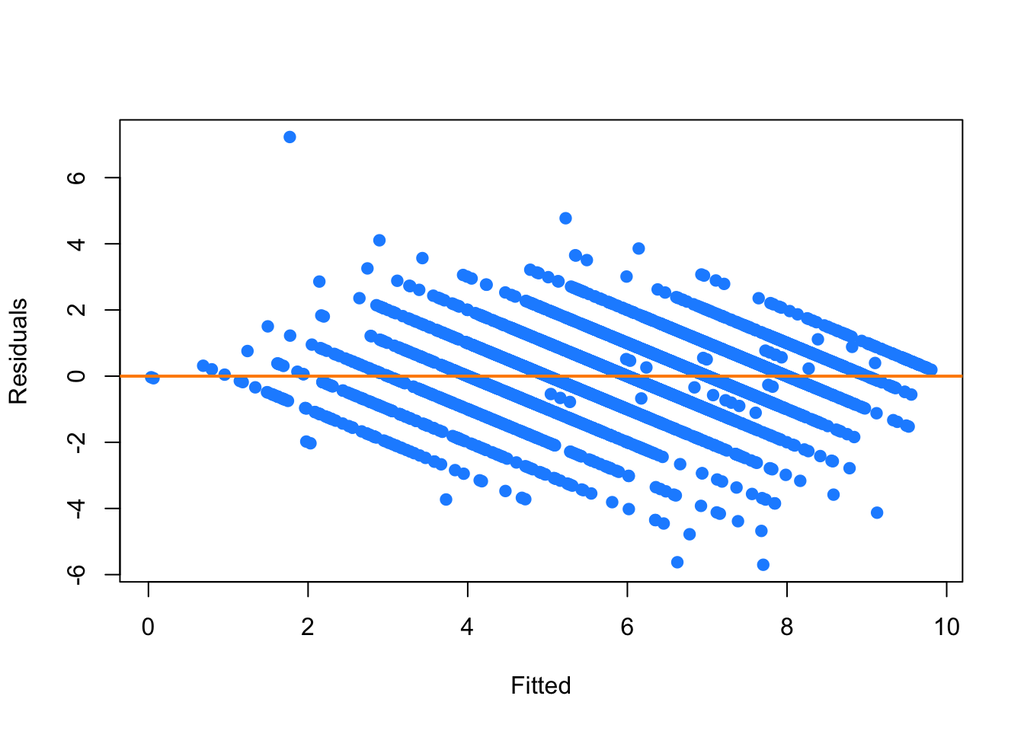

```r
###aic_new
plot_fitted_resid(aic_new)
```

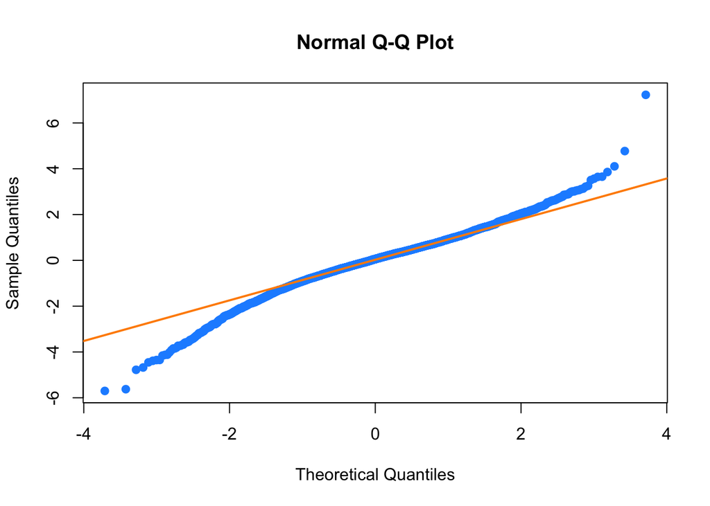

```r
plot_qq(aic_new)
```

```r
#bptest(aic_new)
#shapiro.test(resid(aic_new))
get_bp_decision(aic_new, alpha)
```

```
## [1] "Reject"
```

```r
get_sw_decision(aic_new, alpha)
```

```
## [1] "Reject"
```

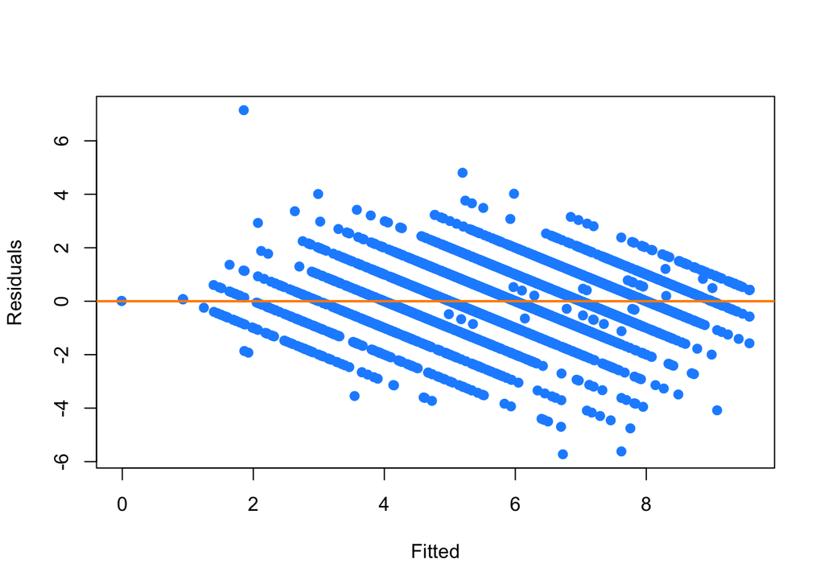

```r
##bic_new
plot_fitted_resid(bic_new)
```

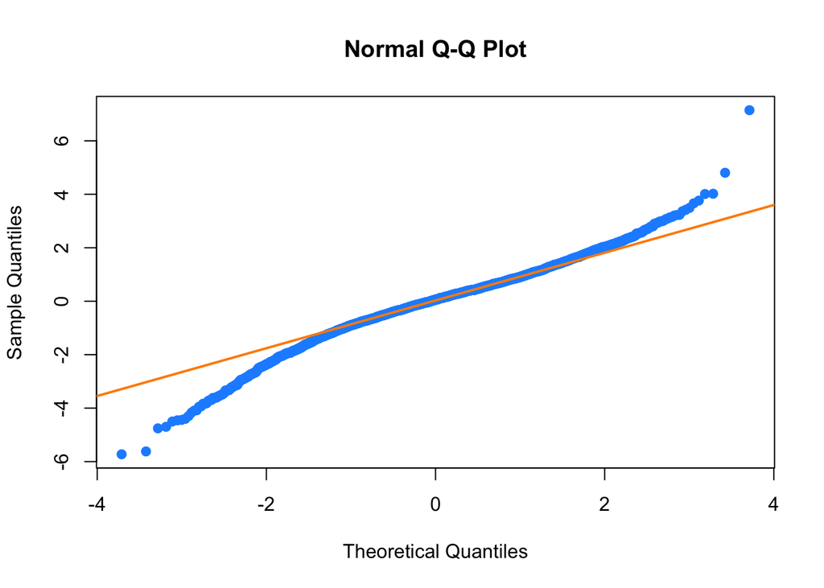

```r
plot_qq(bic_new)
```

```r
#bptest(bic_new)
#shapiro.test(resid(bic_new))
get_bp_decision(bic_new, alpha)
```

```
## [1] "Reject"
```

```r
get_sw_decision(bic_new, alpha)
```

```
## [1] "Reject"
```

##### 3.7.3 Model comparison between aic and bic

Since `aic_new` and `bic_new` are nested, we could conduct an `F` test:

```r
anova(bic_new, aic_new)
```

```
## Analysis of Variance Table
##
## Model 1: like_o ~ attr_o + sinc_o + intel_o + fun_o + shar_o + dec_o +
##     shar_o:dec_o
## Model 2: like_o ~ age_o + attr_o + sinc_o + intel_o + fun_o + shar_o +
##     gender + samerace + match + dec_o + age_o:shar_o + attr_o:samerace +
##     shar_o:dec_o + gender:dec_o
##   Res.Df    RSS Df Sum of Sq      F   Pr(>F)
## 1   4842 5321.9
## 2   4835 5300.3  7    21.628 2.8185 0.006256 **
## ---
## Signif. codes:  0 '***' 0.001 '**' 0.01 '*' 0.05 '.' 0.1 ' ' 1
```

- The null hypothesis

- The test statistic

```r
anova(bic_new, aic_new)[2, "F"]
```

```
## [1] 2.818525
```

- The p-value

```r
anova(bic_new, aic_new)[2, "Pr(>F)"]
```

```
## [1] 0.006256174
```

- A decision

Since the p-value of the test is 0.0062562, pretty small, we reject the null hypothesis and prefer the model with more predictors, which is the `aic_new` model.

Based the `F` test result, we might prefer the model with more predictors, but we would like to compare two models’ value of `LOOCV_RMSE`, maximum VIF, adjusted $R^2$ and number of $\beta$s before jump to any conclusion.

```r
tables_3 = data.frame("max_VIF" = c(max(vif(aic_new)), max(vif(bic_new))), "Number_of_betas" = c(get_num_params(aic_new), get_num_params(bic_new)), "LOOCV_RMSE" = c(get_loocv_rmse(aic_new),  get_loocv_rmse(bic_new)), "adj.R_2" = c(get_adj_r2(aic_new), get_adj_r2(bic_new)))
rownames(tables_3) = c("AIC_new", "BIC_new")
knitr::kable(tables_3)
```

|  | max_VIF | Number_of_betas | LOOCV_RMSE | adj.R_2 |
| --- | --- | --- | --- | --- |
| AIC_new | 66.16065 | 15 | 1.049138 | 0.6830391 |
| BIC_new | 12.87000 | 8 | 1.049728 | 0.6822058 |

From the table above, `bic_new` model has 7 predictors less than `aic_new` model while its value of `LOOCV_RMSE` is only a little bit higher than the `aic_new` model and its adjusted $R^2$ of is only a little bit smaller. With small difference in `LOOCV_RMSE` and adjusted $R^2$ , we’re looking for a smaller and easier-to-interpret model, therefore we come to the conclusion that `bic_new` model is better than `aic_new` model.

##### 3.7.4 Model comparison with simple model

Comparison with `simple_model` (the additive model with all variables)

```r
tables_4 = data.frame("max_VIF" = c(max(vif(simple_model)), max(vif(bic_new))), "Number_of_betas" = c(get_num_params(simple_model), get_num_params(bic_new)), "LOOCV_RMSE" = c(get_loocv_rmse(simple_model), get_loocv_rmse(bic_new)), "adj.R_2" = c(get_adj_r2(simple_model), get_adj_r2(bic_new)))
rownames(tables_4) = c("simple_model", "bic_new")
knitr::kable(tables_4)
```

|  | max_VIF | Number_of_betas | LOOCV_RMSE | adj.R_2 |
| --- | --- | --- | --- | --- |
| simple_model | 2.40103 | 12 | 1.053685 | 0.6800530 |
| bic_new | 12.87000 | 8 | 1.049728 | 0.6822058 |

Based on the table above, `bic_new` model has 4 predictors less than the simple additive model, smaller value of `LOOCV_RMSE` and higher value of adjusted $R^2$. Therefore we will arrive at a conclusion that `bic_new` model is better than `simple_model` model (additive model).

**In conclusion, the “best” model we find in this project would be `bic_new` model. Next, we will go throught some evaluations on this model.**

## Results

Based on the previous sections, we find our “best” model so far using `train_data` subset:

$$\hat{\text{like_o}} = \hat\beta_0 + \hat\beta_1 x_{\text{attr_o}} + \hat\beta_2 x_{\text{sinc_o}} + \hat\beta_3 x_{\text{intel_o}} + \hat\beta_4 x_{\text{fun_o}} + \hat\beta_5 x_{\text{shar_o}} + \hat\beta_6 x_{\text{dec_o}} + \hat\beta_7 x_{\text{shar_o}} x_{\text{dec_o}}$$

- `dec_o` is the dummy variable, $\text{dec_o} = 1$ when making the decision to see partner again, $\text{dex_o} = 0$ when making the decision not to see partner again.

### 1. Summary of the “best” model

```r
summary(bic_new)
```

```
##
## Call:
## lm(formula = like_o ~ attr_o + sinc_o + intel_o + fun_o + shar_o +
##     dec_o + shar_o:dec_o, data = train_data)
##
## Residuals:
##     Min      1Q  Median      3Q     Max
## -5.7263 -0.5745  0.0580  0.6303  7.1458
##
## Coefficients:
##               Estimate Std. Error t value Pr(>|t|)
## (Intercept)   -0.01035    0.08341  -0.124    0.901
## attr_o         0.25872    0.01043  24.795  < 2e-16 ***
## sinc_o         0.13163    0.01201  10.959  < 2e-16 ***
## intel_o        0.10463    0.01341   7.801 7.48e-15 ***
## fun_o          0.18785    0.01147  16.378  < 2e-16 ***
## shar_o         0.25362    0.01129  22.470  < 2e-16 ***
## dec_o1         1.11139    0.09887  11.240  < 2e-16 ***
## shar_o:dec_o1 -0.08910    0.01584  -5.626 1.95e-08 ***
## ---
## Signif. codes:  0 '***' 0.001 '**' 0.01 '*' 0.05 '.' 0.1 ' ' 1
##
## Residual standard error: 1.048 on 4842 degrees of freedom
## Multiple R-squared:  0.6827, Adjusted R-squared:  0.6822
## F-statistic:  1488 on 7 and 4842 DF,  p-value: < 2.2e-16
```

```r
coef(bic_new)
```

```
##   (Intercept)        attr_o        sinc_o       intel_o         fun_o
##   -0.01035478    0.25871659    0.13163310    0.10462887    0.18785166
##        shar_o        dec_o1 shar_o:dec_o1
##    0.25361607    1.11138679   -0.08910276
```

```r
bptest(bic_new)$p.value
```

```
##           BP
## 9.986795e-34
```

```r
shapiro.test(resid(bic_new))$p.value
```

```
## [1] 7.290829e-27
```

### 2. Use `test` data to evaluate model

- calculate the average percent error:
  $$\frac{1}{n}\sum_i\frac{|\text{predicted}_i - \text{actual}_i|}{\text{predicted}_i} \times 100$$
- Plot the predicted versus the actual values and add the line $y = x$.

```r
get_prec_err(predict(bic_new, test_data), test_data$like_o)
```

```
## [1] 0.1428345
```

The average percent error of `bic_new` model is around 14.28%, which is acceptable.

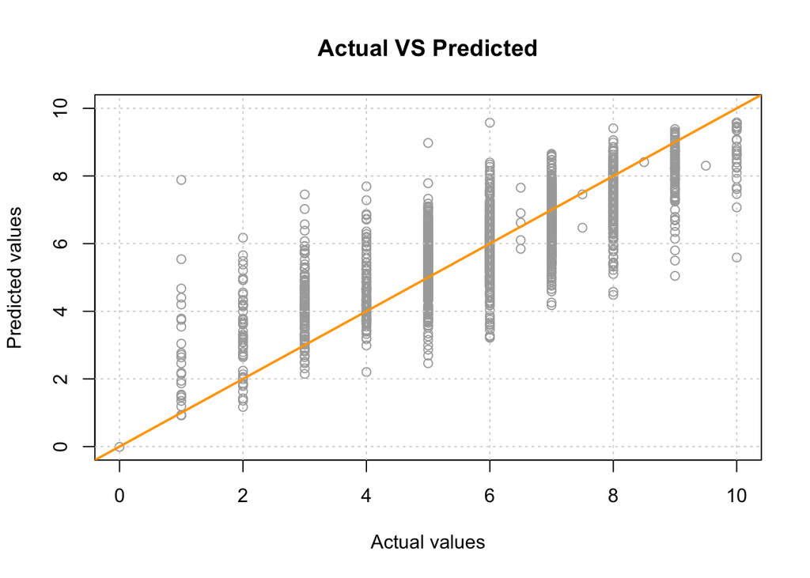

```r
plot(test_data$like_o, predict(bic_new, test_data), xlim = c(0, 10), ylim = c(0, 10), col = "darkgrey", xlab = "Actual values", ylab = "Predicted values", main = "Actual VS Predicted")
grid()
abline(0, 1, col = "orange", lwd = 2)
```

## Discussion

### 1. Explanation of the model in the context of the data

```r
coef(bic_new)
```

```
##   (Intercept)        attr_o        sinc_o       intel_o         fun_o
##   -0.01035478    0.25871659    0.13163310    0.10462887    0.18785166
##        shar_o        dec_o1 shar_o:dec_o1
##    0.25361607    1.11138679   -0.08910276
```

Based on the previous sections, we could derive the following formula:

$$\hat{\text{like_o}} = \hat\beta_0 + \hat\beta_1 x_{\text{attr_o}} + \hat\beta_2 x_{\text{sinc_o}} + \hat\beta_3 x_{\text{intel_o}} + \hat\beta_4 x_{\text{fun_o}} + \hat\beta_5 x_{\text{shar_o}} + \hat\beta_6 x_{\text{dec_o}} + \hat\beta_7 x_{\text{shar_o}} x_{\text{dec_o}}$$

- $\hat{\beta_0}$ = -0.0103548, is the estimated mean ratings of like for a participant who receives **0 for attractiveness, 0 for sincere, 0 for intelligent, 0 for fun, 0 for shared interests/hobbies** from his/her speed dating partner and the partner expresses **no interest** to see him/her again(poor boy/girl!)
- $\hat{\beta_1}$ = 0.2587166, is the estimated average change in ratings of like for an increase of 1-point in **attractive** for a participant who receives a fixed score of sincere, intelligent, fun and shared interests/hobbies from his/her speed dating partner
- $\hat{\beta_2}$ = 0.1316331, is the estimated average change in ratings of like for an increase of 1-point in **sincere** for a participant who receives a fixed score of attractive, intelligent, fun and shared interests/hobbies from his/her speed dating partner
- $\hat{\beta_3}$ = 0.1046289, is the estimated average change in ratings of like for an increase of 1-point in **intelligent** for a participant who receives a fixed score of attractive, sincere, fun and shared interests/hobbies from his/her speed dating partner
- $\hat{\beta_4}$ = 0.1878517, is the estimated average change in ratings of like for an increase of 1-point in **fun** for a participant who receives a fixed score of attractive, sincere, intelligent and shared interests/hobbies from his/her speed dating partner
- $\hat{\beta_5}$ = 0.2536161, is the estimated average change in ratings of like for an increase of 1-point in **shared interests/hobbies** for a participant who receives a fixed score of attractive, sincere, intelligent and fun from his/her speed dating partner and the partner expresses **no interest** to see him/her again
- $\hat{\beta_6}$ = 1.1113868, is the estimate for $\beta_6$, the estimated **difference** in mean ratings of like for a participant who receives 0 for attractiveness, 0 for sincere, 0 for intelligent, 0 for fun, 0 for shared interests/hobbies from his/her speed dating partner between whether the partner expresses interest to see him/her again
- $\hat{\beta_0} + \hat{\beta_6}$ = 1.101032, is the estimated mean ratings of like for a participant who receives **0 for attractiveness, 0 for sincere, 0 for intelligent, 0 for fun, 0 for shared interests/hobbies** from his/her speed dating partner and the partner expresses **interest** to see him/her again
- $\hat{\beta_7}$ = -0.0891028, is the estimated **difference** in mean ratings of like for an increase of 1-point in **shared interests/hobbies** for a participant who receives a fixed score of attractive, sincere, intelligent and fun from his/her speed dating partner between whether the partner expresses no interest to see him/her again
- $\hat{\beta_5} + \hat{\beta_7}$ = 0.1645133,is the estimated average change in ratings of like for an increase of 1-point in **shared interests/hobbies** for a participant who receives a fixed score of attractive, sincere, intelligent and fun from his/her speed dating partner and the partner expresses **interest** to see him/her again

```r
#coef(bic_new)
beta_0_hat = coef(bic_new)[1]
beta_1_hat = coef(bic_new)[2]
beta_2_hat = coef(bic_new)[3]
beta_3_hat = coef(bic_new)[4]
beta_4_hat = coef(bic_new)[5]
beta_5_hat = coef(bic_new)[6]
beta_6_hat = coef(bic_new)[7]
beta_7_hat = coef(bic_new)[8]
```

Since we have one dummy variable in the model, `dec_o`, we would like to consider two different scenarios: $\text{dec_o} = 0$ when the participant makes a decision not to see partner again. And $\text{dec_o} = 1$ when the participant makes a decision to see partner again.

Scenario 1: $\text{dec_o} = 0$

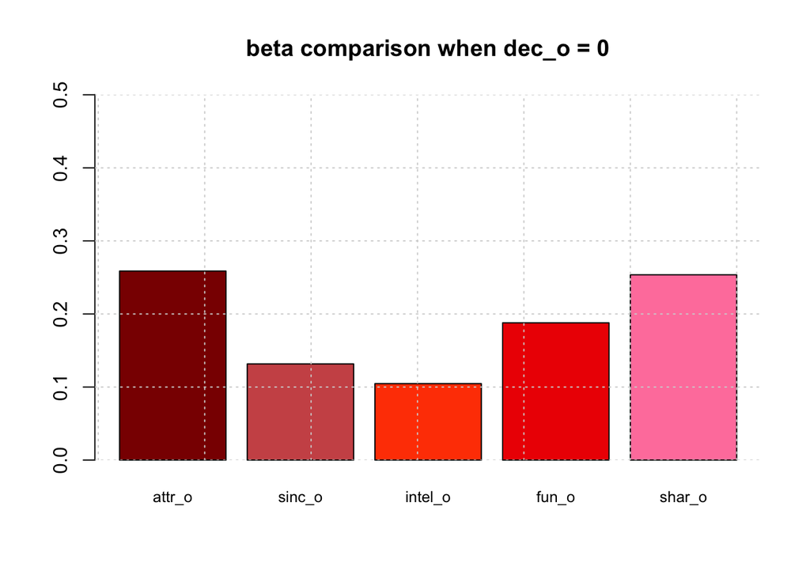

```r
dec_o_0 = coef(bic_new)[2:6]
barplot(dec_o_0, ylim = c(0, 0.5), cex.names = 0.8, col = c("darkred", "indianred3", "orangered1", "red2" , "palevioletred1"), main = "beta comparison when dec_o = 0")
grid()
```

From the plot above, we can see that how people rate their partners on attrativeness and shared-interest have the strongest correlation on their rating of how much they like their partners **when they decide not to see them again**; fun and sincerity follow and intelligence has the least correlation in the model.

Scenario 2: $\text{dec_o} = 1$

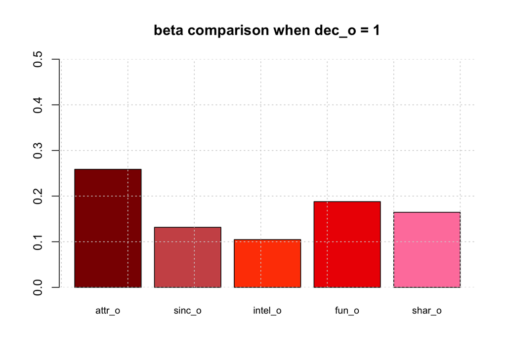

```r
dec_o_1 = c(beta_1_hat, beta_2_hat, beta_3_hat, beta_4_hat, beta_5_hat + beta_7_hat)
barplot(dec_o_1, ylim = c(0, 0.5), cex.names = 0.8, col = c("darkred", "indianred3", "orangered1", "red2" , "palevioletred1"), main = "beta comparison when dec_o = 1")
grid()
```

From the plot above, we can see that **when people decide to see their partners again**, the correlation between how they rate their partners on like and rate on shared-interest drops a little; attrativeness remains the strongest correlation and the rest of variables stay the same.

### 2. Explore answers to the following questions

- Does age difference correlate with how people like their partners?

According to our model, no.

- Does gender difference correlate with how people like their partners?

According to our model, no.

- Does race difference correlate with how people like their partners?

According to our model, no.

- Does match correlate with how people like their partners?

According to our model, no (this result is a little suspicious, need more work to be done in future).

- Does attractiveness correlate with how people like their partners?

According to our model, yes, attractiveness has one of strongest correlations.

- Does sincerity correlate with how people like their partners?

According to our model, yes, sincerity has some correlation.

- Does intellingence correlate with how people like their partners?

According to our model, yes, intellingence has some correlation.

- Does being fun correlate with how people like their partners?

According to our model, yes, fun has one of strongest correlations.

- Does ambition correlate with how people like their partners?

According to our model, no.

- Does shared-interests correlate with how people like their partners?

According to our model, yes, shared-interests has one of strongest correlations.

- Does decision to see the partner again correlate with how people like their partners?

According to our model, yes, different decision have difference influence on how shared-interests relates with how people like their partners.

### 3. Why no transformation of response

```r
sum(train_data$like_o == 0)
```

```
## [1] 5
```

Since our reponse has non-positive value 0 (only 5 observations), we need to remove them before try box-cox transformation.

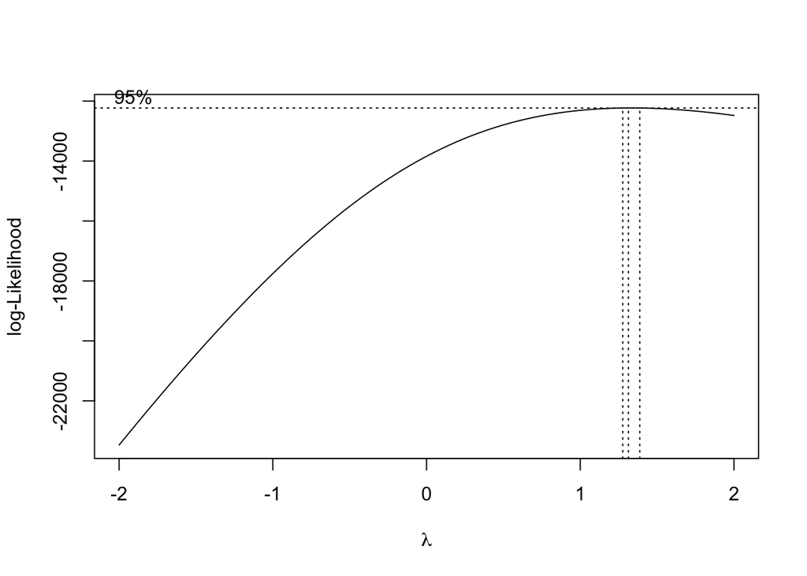

```r
bc_train = train_data[train_data$like_o > 0,]
bc_model = lm(like_o ~ . , data = bc_train)
boxcox(bc_model, plotit = TRUE)
```

From the plot above, we see that optimal $\lambda$ is around 1.3, which suggests we use transformation as below:

```r
bc_try = lm((like_o^1.3-1)/1.3 ~ . , data = bc_train)
summary(bc_try)
```

```
##
## Call:
## lm(formula = (like_o^1.3 - 1)/1.3 ~ ., data = bc_train)
##
## Residuals:
##     Min      1Q  Median      3Q     Max
## -8.5523 -1.0203  0.0512  1.0563 11.9970
##
## Coefficients:
##              Estimate Std. Error t value Pr(>|t|)
## (Intercept) -2.613504   0.238502 -10.958  < 2e-16 ***
## age_o        0.004324   0.007338   0.589    0.556
## attr_o       0.430361   0.017580  24.480  < 2e-16 ***
## sinc_o       0.215085   0.020092  10.705  < 2e-16 ***
## intel_o      0.167029   0.024998   6.682 2.63e-11 ***
## fun_o        0.322664   0.019389  16.642  < 2e-16 ***
## amb_o        0.006739   0.019074   0.353    0.724
## shar_o       0.359148   0.015757  22.793  < 2e-16 ***
## gender1      0.054149   0.052035   1.041    0.298
## samerace1    0.052274   0.051461   1.016    0.310
## match1       0.103491   0.078378   1.320    0.187
## dec_o1       0.995871   0.067134  14.834  < 2e-16 ***
## ---
## Signif. codes:  0 '***' 0.001 '**' 0.01 '*' 0.05 '.' 0.1 ' ' 1
##
## Residual standard error: 1.747 on 4833 degrees of freedom
## Multiple R-squared:  0.6819, Adjusted R-squared:  0.6812
## F-statistic: 941.9 on 11 and 4833 DF,  p-value: < 2.2e-16
```

```r
get_adj_r2(simple_model)
```

```
## [1] 0.680053
```

```r
get_adj_r2(bc_try)
```

```
## [1] 0.6811871
```

```r
get_loocv_rmse(simple_model)
```

```
## [1] 1.053685
```

```r
get_loocv_rmse(bc_try)
```

```
## [1] 1.749644
```

```r
com_tables = data.frame("LOOCV_RMSE" = c(get_loocv_rmse(simple_model), get_loocv_rmse(bc_try)), "adj.R_2" = c(get_adj_r2(simple_model), get_adj_r2(bc_try)))
rownames(com_tables) = c("Simple model", "Box-Cox model")
knitr::kable(com_tables)
```

|  | LOOCV_RMSE | adj.R_2 |
| --- | --- | --- |
| Simple model | 1.053685 | 0.6800530 |
| Box-Cox model | 1.749644 | 0.6811871 |

From above table we can see that, the `Box-Cox` model’s adjusted $R^2$ increases by only 0.166766%, however, its `LOOCV_RMSE` increases by quite a large percentage, so we decide not to use transformation on response variable.

### 4. Why no polynomial transformation of predictors?

```r
model_pol = lm(like_o ~ . +  poly(age_o, 2) + poly(attr_o, 2)+poly(sinc_o, 2)+poly(intel_o, 2)+poly(fun_o, 2)+poly(amb_o, 2)+poly(shar_o, 2) , data = train_data)
#summary(model_pol)$coef
aic_pol = step(model_pol, direction = "backward", k = 2, trace = 0)
bic_pol = step(model_pol, direction = "backward", k = log(length(resid(model_pol))), trace = 0)
max(vif(aic_pol))
```

```
## [1] 2.222108
```

```r
max(vif(bic_pol))
```

```
## [1] 2.220496
```

```r
get_num_params(aic_pol)
```

```
## [1] 14
```

```r
get_num_params(bic_pol)
```

```
## [1] 12
```

```r
#all.equal(names(coef(aic_pol)), names(coef(bic_pol)))
summary(bic_pol)$coef[1:12, 4] < alpha
```

```
##       (Intercept)            dec_o1  poly(attr_o, 2)1  poly(attr_o, 2)2
##              TRUE              TRUE              TRUE             FALSE
##  poly(sinc_o, 2)1  poly(sinc_o, 2)2 poly(intel_o, 2)1 poly(intel_o, 2)2
##              TRUE             FALSE              TRUE             FALSE
##   poly(fun_o, 2)1   poly(fun_o, 2)2  poly(shar_o, 2)1  poly(shar_o, 2)2
##              TRUE             FALSE              TRUE             FALSE
```

```r
get_loocv_rmse(bic_pol)
```

```
## [1] 1.053523
```

```r
get_adj_r2(bic_pol)
```

```
## [1] 0.6804699
```

```r
get_bp_decision(bic_pol, alpha)
```

```
## [1] "Reject"
```

```r
get_sw_decision(bic_pol, alpha)
```

```
## [1] "Reject"
```

We’re using backward AIC and BIC again, starting with a model with quadratic terms for all posibile variables. BIC selects a model with 2 predictors less than AIC and all quadratic terms are **not significant**.

### 5. Will the result change if the starting model has less attributes?

Based on the previous section, the additive model with all variables has the smallest maxmimum VIF among all the models, which is 2.4010298. We will discuss if result changes when model selection starts with an additive model containing six attributes.

```r
model_test = lm(like_o ~ attr_o + sinc_o + intel_o + fun_o + amb_o + shar_o, data = train_data)
summary(model_test)$coef
```

```
##                Estimate  Std. Error   t value      Pr(>|t|)
## (Intercept) -0.07411262 0.080300587 -0.922940  3.560845e-01
## attr_o       0.31280066 0.010223827 30.595262 4.166834e-188
## sinc_o       0.12098679 0.012367174  9.782897  2.147132e-22
## intel_o      0.10581001 0.015360816  6.888306  6.367782e-12
## fun_o        0.21595782 0.011848058 18.227276  7.543989e-72
## amb_o       -0.01354205 0.011672230 -1.160194  2.460270e-01
## shar_o       0.24292997 0.009601979 25.299989 9.548202e-133
```

```r
max(vif(model_test))
```

```
## [1] 2.383576
```

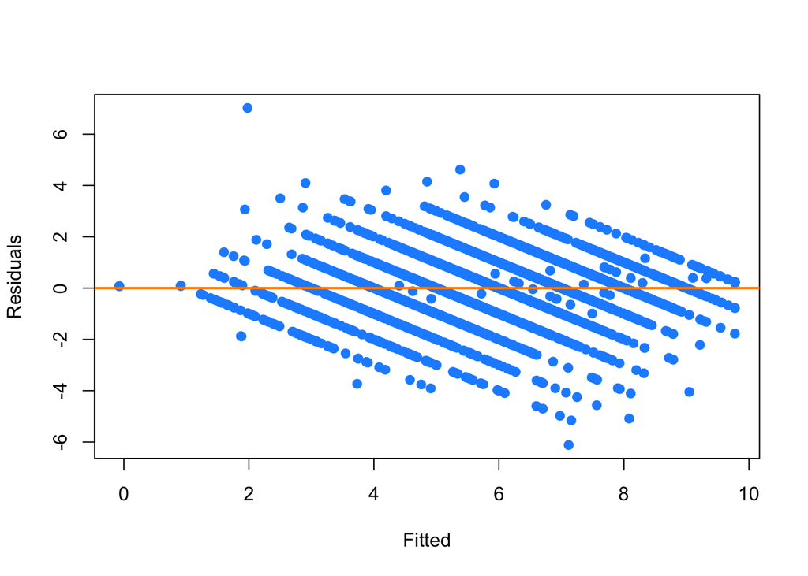

```r
plot_fitted_resid(model_test)
```

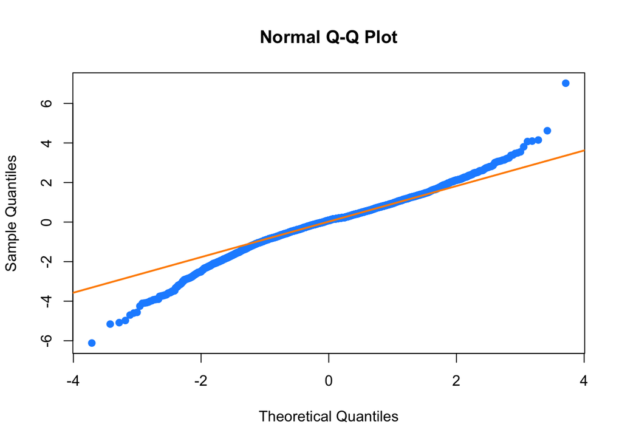

```r
plot_qq(model_test)
```

```r
get_bp_decision(model_test, alpha)
```

```
## [1] "Reject"
```

```r
get_sw_decision(model_test, alpha)
```

```
## [1] "Reject"
```

```r
get_num_params(model_test)
```

```
## [1] 7
```

```r
get_loocv_rmse(model_test)
```

```
## [1] 1.082024
```

```r
get_adj_r2(model_test)
```

```
## [1] 0.6623047
```

##### 5.1 AIC and BIC selection procedures

```r
aic_test = step(model_test, direction = "backward", k = 2, trace = 0)
bic_test = step(model_test, direction = "backward", k = log(length(resid(model_test))), trace = 0)
all.equal(names(coef(aic_test)), names(coef(bic_test)))
```

```
## [1] TRUE
```

```r
summary(aic_test)$coef
```

```
##                Estimate Std. Error   t value      Pr(>|t|)
## (Intercept) -0.08639951 0.07960202 -1.085393  2.778015e-01
## attr_o       0.31261943 0.01022300 30.580014 6.117256e-188
## sinc_o       0.12111050 0.01236716  9.792915  1.948202e-22
## intel_o      0.09802117 0.01381661  7.094445  1.486380e-12
## fun_o        0.21387008 0.01171103 18.262282  4.138277e-72
## shar_o       0.24142122 0.00951385 25.375764 1.741470e-133
```

```r
max(vif(aic_test))
```

```
## [1] 2.182234
```

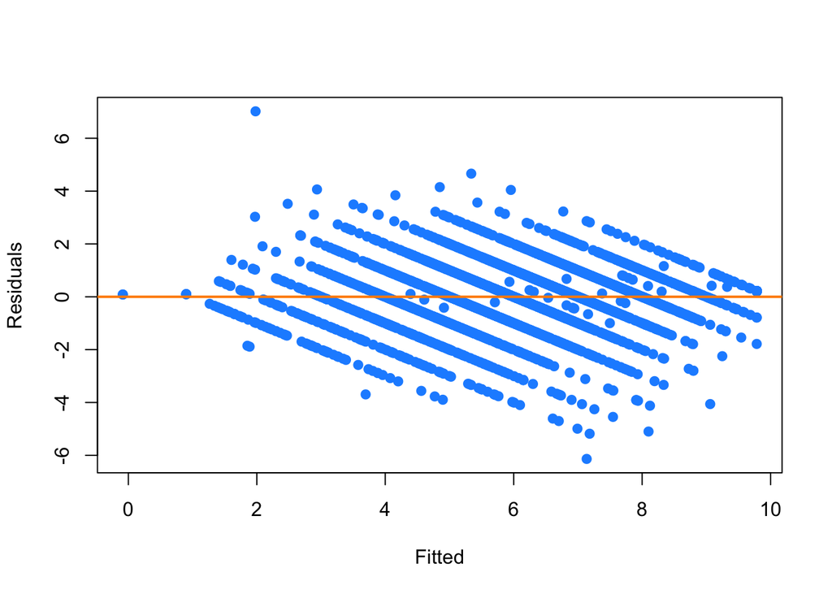

```r
plot_fitted_resid(aic_test)
```

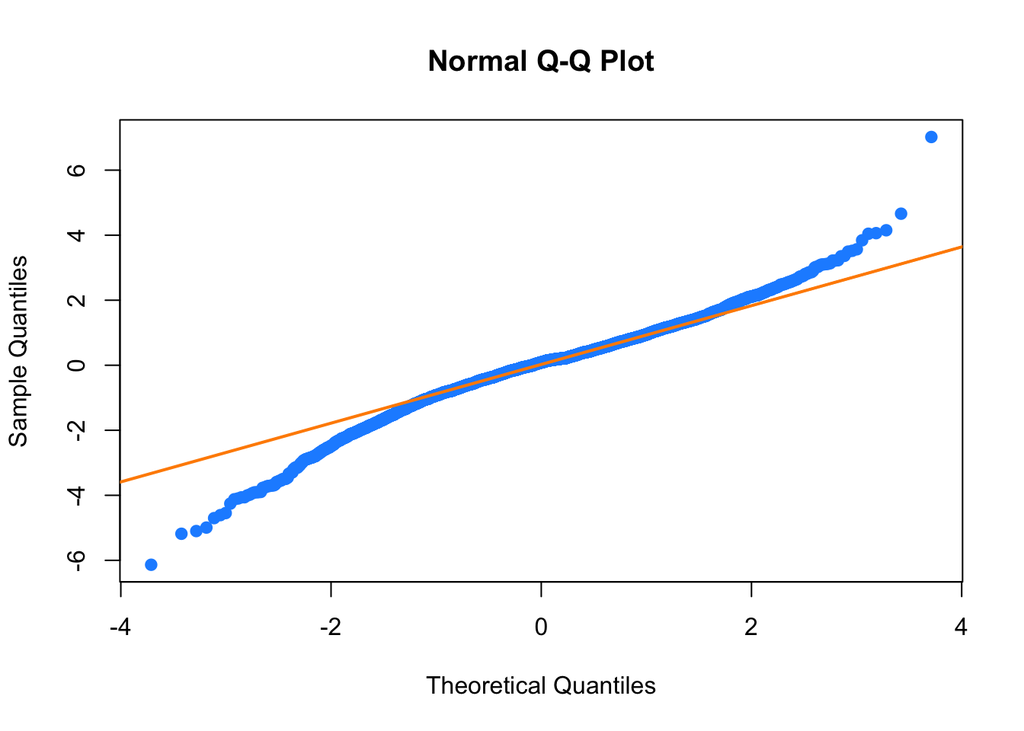

```r
plot_qq(aic_test)
```

```r
get_bp_decision(aic_test, alpha)
```

```
## [1] "Reject"
```

```r
get_sw_decision(aic_test, alpha)
```

```
## [1] "Reject"
```

```r
get_num_params(aic_test)
```

```
## [1] 6
```

```r
get_loocv_rmse(aic_test)
```

```
## [1] 1.081884
```

```r
get_adj_r2(aic_test)
```

```
## [1] 0.6622806
```

Both AIC and BIC select the same model.

##### 5.2 Model Comparison

Next, make a table to list maximum VIF, number of $\beta$, `LOOCV_RMSE` and adjusted $R^2$ for comparison with `aic_test` model and `bic_new` model.

```r
tables_5 = data.frame("max_VIF" = c(max(vif(aic_test)), max(vif(bic_new))), "Number_of_betas" = c(get_num_params(aic_test), get_num_params(bic_new)), "LOOCV_RMSE" = c(get_loocv_rmse(aic_test), get_loocv_rmse(bic_new)), "adj.R_2" = c(get_adj_r2(aic_test), get_adj_r2(bic_new)))
rownames(tables_5) = c("AIC_test", "BIC_new")
knitr::kable(tables_5)
```

|  | max_VIF | Number_of_betas | LOOCV_RMSE | adj.R_2 |
| --- | --- | --- | --- | --- |
| AIC_test | 2.182234 | 6 | 1.081884 | 0.6622806 |
| BIC_new | 12.870002 | 8 | 1.049728 | 0.6822058 |

Next, make an `F` test between two models.

```r
anova(aic_test, bic_new)
```

```
## Analysis of Variance Table
##
## Model 1: like_o ~ attr_o + sinc_o + intel_o + fun_o + shar_o
## Model 2: like_o ~ attr_o + sinc_o + intel_o + fun_o + shar_o + dec_o +
##     shar_o:dec_o
##   Res.Df    RSS Df Sum of Sq      F    Pr(>F)
## 1   4844 5657.9
## 2   4842 5321.9  2    336.01 152.86 < 2.2e-16 ***
## ---
## Signif. codes:  0 '***' 0.001 '**' 0.01 '*' 0.05 '.' 0.1 ' ' 1
```

The null hypothesis: $\beta_\text{dec_o} = \beta_\text{shar_o:dec_o} = 0$

Decision:

Based on the p-value of above `F` test is pretty small, we reject the null hypothesis, so we prefer the larger model (`bic_new` model, the previous “best” model).

**In conclusion, the “best” model remains the same even when we start a model with less selected attributes.**

### 6. Outlier diagnostics

##### 6.1 Check high leverage:

```r
hat_values_aic = hatvalues(aic_new)[hatvalues(aic_new) > 2 * mean(hatvalues(aic_new))]
hat_values_bic = hatvalues(bic_new)[hatvalues(bic_new) > 2 * mean(hatvalues(bic_new))]
length(hat_values_aic)
```

```
## [1] 260
```

```r
length(hat_values_bic)
```

```
## [1] 373
```

We could say that there are 260 observations in `aic_new` model and 373 observations in `bic_new` model that are points of high leverage with great **potential** influence on the model.

##### 6.2 Check influential observations:

```r
cooks_dis_aic = cooks.distance(aic_new)[cooks.distance(aic_new) > 4 / length(cooks.distance(aic_new))]
cooks_dis_bic = cooks.distance(bic_new)[cooks.distance(bic_new) > 4 / length(cooks.distance(bic_new))]
length(cooks_dis_aic)
```

```
## [1] 315
```

```r
length(cooks_dis_bic)
```

```
## [1] 343
```

##### 6.3 Refit the selected models by removing any observations identified as influential and compare with the old pair of models:

```r
###remove the influential boservations in aic model
int_model_sub_aic = lm(like_o ~ . + age_o : shar_o + attr_o : samerace + shar_o : dec_o + gender : dec_o, data = train_data, subset = cooks.distance(aic_new) <= 4 / length(cooks.distance(aic_new)))
###remove the influential boservations in bic model
int_model_sub_bic = lm(like_o ~ . + age_o : shar_o + attr_o : samerace + shar_o : dec_o + gender : dec_o, data = train_data, subset = cooks.distance(bic_new) <= 4 / length(cooks.distance(bic_new)))
aic_new_sub = step(int_model_sub_aic, direction = "backward", trace = 0)
bic_new_sub = step(int_model_sub_bic, direction = "backward", k = log(nrow(train_data)), trace = 0)
```

Compare with maximum VIF and number of predictors.

```r
max(vif(aic_new_sub))
```

```
## [1] 70.62833
```

```r
max(vif(bic_new_sub))
```

```
## [1] 14.30125
```

```r
length(coef(aic_new_sub))
```

```
## [1] 13
```

```r
length(coef(bic_new_sub))
```

```
## [1] 8
```

```r
#all.equal(names(coef(aic_new)), names(coef(aic_new_sub)))
all.equal(names(coef(bic_new)), names(coef(bic_new_sub)))
```

```
## [1] TRUE
```

```r
get_bp_decision(aic_new_sub, alpha)
```

```
## [1] "Reject"
```

```r
get_bp_decision(bic_new_sub, alpha)
```

```
## [1] "Reject"
```

```r
get_sw_decision(aic_new_sub, alpha)
```

```
## [1] "Reject"
```

```r
get_sw_decision(bic_new_sub, alpha)
```

```
## [1] "Reject"
```

From the above code, we could tell that by removing the influential observations, the aic model gets two predcitors less and bic model’s number of predictors remains the same.

Compare with `LOOCV_RMSE`, numbers of $\beta$, maximum VIF and adjusted $R ^ 2$ of two paris of selected models

```r
tables_2 = data.frame("max_VIF" = c(max(vif(aic_new)), max(vif(aic_new_sub)), max(vif(bic_new)), max(vif(bic_new_sub))), "Number_of_betas" = c(get_num_params(aic_new), get_num_params(aic_new_sub), get_num_params(bic_new), get_num_params(bic_new_sub)), "LOOCV_RMSE" = c(get_loocv_rmse(aic_new), get_loocv_rmse(aic_new_sub), get_loocv_rmse(bic_new), get_loocv_rmse(bic_new_sub)), "adj.R_2" = c(get_adj_r2(aic_new), get_adj_r2(aic_new_sub), get_adj_r2(bic_new), get_adj_r2(bic_new_sub)))
rownames(tables_2) = c("AIC_new", "AIC_new_sub", "BIC_new", "BIC_new_sub")
knitr::kable(tables_2)
```

|  | max_VIF | Number_of_betas | LOOCV_RMSE | adj.R_2 |
| --- | --- | --- | --- | --- |
| AIC_new | 66.16065 | 15 | 1.0491384 | 0.6830391 |
| AIC_new_sub | 70.62833 | 13 | 0.8329695 | 0.7743357 |
| BIC_new | 12.87000 | 8 | 1.0497282 | 0.6822058 |
| BIC_new_sub | 14.30125 | 8 | 0.8266071 | 0.7768196 |

From the table above, for both `aic_new` model and `bic_new` model, their `LOOCV_RMSE` decreases and adjusted $R^2$ increases which are expected by removing the influential observations. However, **both models’ max VIF increase which is considered as a drawback**.

Next, we will evaluate the two new subset models by calculating the average precentage error and compare the values of average precentage error without removing influential observations.

```r
erro_1 = get_prec_err(predict(aic_new, test_data), test_data$like_o)
erro_2 = get_prec_err(predict(aic_new_sub, test_data), test_data$like_o)
erro_3 = get_prec_err(predict(bic_new, test_data), test_data$like_o)
erro_4 = get_prec_err(predict(bic_new_sub, test_data), test_data$like_o)
```

```r
tables_erro = data.frame("Average_percentage_error" = c(erro_1, erro_2, erro_3, erro_4))
rownames(tables_erro) = c("AIC_new", "AIC_new_sub", "BIC_new", "BIC_new_sub")
knitr::kable(tables_erro)
```

|  | Average_percentage_error |
| --- | --- |
| AIC_new | 0.1432690 |
| AIC_new_sub | 0.1432872 |
| BIC_new | 0.1428345 |
| BIC_new_sub | 0.1427554 |

**When apply the models to test data, we don’t see error rate drop dramatically. Besides, the quantity of influential observations is less than 10% of total quantity of `train_data` subset observations, therefore we decide not to remove any outlier at this stage.**

In conclusion, our “best” model stays the same as following:

$$\hat{\text{like_o}} = \hat\beta_0 + \hat\beta_1 x_{\text{attr_o}} + \hat\beta_2 x_{\text{sinc_o}} + \hat\beta_3 x_{\text{intel_o}} + \hat\beta_4 x_{\text{fun_o}} + \hat\beta_5 x_{\text{shar_o}} + \hat\beta_6 x_{\text{dec_o}} + \hat\beta_7 x_{\text{shar_o}} x_{\text{dec_o}}$$

## Appendix

- Overview of the whole data set, `train_data` subset and `test_data` subset

```r
###data_set
head(selected_data, 20)
```

```
##    age_o attr_o sinc_o intel_o fun_o amb_o shar_o like_o gender samerace
## 1     27      6      8       8     8     8      6    7.0      0        0
## 2     22      7      8      10     7     7      5    8.0      0        0
## 3     22     10     10      10    10    10     10   10.0      0        1
## 4     23      7      8       9     8     9      8    7.0      0        0
## 5     24      8      7       9     6     9      7    8.0      0        0
## 6     25      7      7       8     8     7      7    7.0      0        0
## 7     30      3      6       7     5     8      7    2.0      0        0
## 8     27      6      7       5     6     8      6    7.0      0        0
## 9     28      7      7       8     8     8      9    6.5      0        0
## 10    24      6      6       6     6     6      6    6.0      0        0
## 11    27      8      7       6     9     7      4    7.0      0        1
## 12    22      7      6      10     6     6      5    8.0      0        1
## 13    22     10     10      10    10    10     10   10.0      0        0
## 14    23      9      9       9     9     9      9    9.0      0        1
```

[output cut: 27 more lines]

```r
###train_data
head(train_data, 20)
```

```
##      age_o attr_o sinc_o intel_o fun_o amb_o shar_o like_o gender samerace
## 2232    28      3      5       7     2     5      2    1.0      1        1
## 3092    24      7      8       7     6     8      3    4.0      1        0
## 4742    33      6      7       9     6     9      6    7.0      1        0
## 7594    32      3      4       5     4     5      6    5.0      0        0
## 1679    22      5      6       8     7     7      7    7.0      0        0
## 7515    30      7      7       6     8     7      4    7.0      0        1
## 7874    26      7      8       8     7     8      9    7.0      0        1
## 5468    26      6      6       6     6     6      6    7.0      1        0
## 5204    29      8      8       6     8     9      7    7.0      0        1
## 503     28      3      8       7     8     7      5    6.0      0        0
## 1712    22      7      7       8     8    10      6    7.0      0        1
## 1476    29      7      6       7     6     7      6    6.5      1        0
## 5742    26      7      7       7     6     7      6    6.0      1        0
## 3199    26      6      6       7     6     7      6    6.0      1        1
```

[output cut: 27 more lines]

```r
###test_data
head(test_data, 20)
```

```
##    age_o attr_o sinc_o intel_o fun_o amb_o shar_o like_o gender samerace
## 1     27      6      8       8     8     8      6    7.0      0        0
## 2     22      7      8      10     7     7      5    8.0      0        0
## 5     24      8      7       9     6     9      7    8.0      0        0
## 9     28      7      7       8     8     8      9    6.5      0        0
## 20    24      6      5       7     7     9      7    6.0      0        1
## 21    27      7      8       6     5     8      4    5.0      0        1
## 23    22     10     10      10    10    10     10   10.0      0        0
## 24    23      7      9       8     8     8      8    7.0      0        1
## 28    27      4      5       6     4     6      4    5.0      0        1
## 29    28      7      7       6     8     7      7    7.0      0        1
## 32    22      6      5      10     6     6      5    6.0      0        1
## 39    28      7      7       7    10     9     10    8.0      0        1
## 40    24      7      8       8     7     8      7    7.0      0        1
## 46    25      5      8       7     7     7      7    6.0      0        1
```

[output cut: 27 more lines]

```r
str(selected_data)
```

```
## 'data.frame':    6929 obs. of  12 variables:
##  $ age_o   : num  27 22 22 23 24 25 30 27 28 24 ...
##  $ attr_o  : num  6 7 10 7 8 7 3 6 7 6 ...
##  $ sinc_o  : num  8 8 10 8 7 7 6 7 7 6 ...
##  $ intel_o : num  8 10 10 9 9 8 7 5 8 6 ...
##  $ fun_o   : num  8 7 10 8 6 8 5 6 8 6 ...
##  $ amb_o   : num  8 7 10 9 9 7 8 8 8 6 ...
##  $ shar_o  : num  6 5 10 8 7 7 7 6 9 6 ...
##  $ like_o  : num  7 8 10 7 8 7 2 7 6.5 6 ...
##  $ gender  : Factor w/ 2 levels "0","1": 1 1 1 1 1 1 1 1 1 1 ...
##  $ samerace: Factor w/ 2 levels "0","1": 1 1 2 1 1 1 1 1 1 1 ...
##  $ match   : Factor w/ 2 levels "0","1": 1 1 2 2 2 1 1 1 2 1 ...
##  $ dec_o   : Factor w/ 2 levels "0","1": 1 1 2 2 2 2 1 1 2 1 ...
```

- Pairs plot

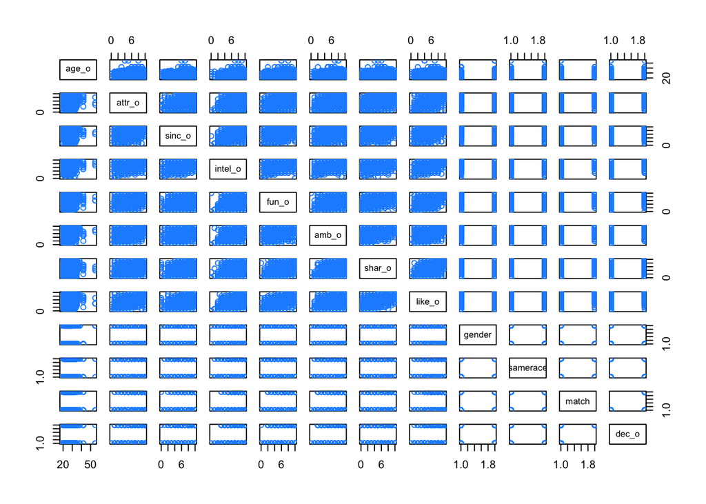

```r
pairs(train_data, col = "dodgerblue")
```

- Observations with high leverage

```r
###in aic_new model
hat_values_aic
```

```
##        7780        3174        5518        6868        4383        2469
## 0.007862087 0.008922160 0.010138339 0.017747491 0.006679090 0.007859167
##        8322        7244        1746          92        5911        4837
## 0.007588122 0.007666818 0.008737843 0.009870675 0.006298299 0.008958211
##        1482        7372        4104        7157        1767        4193
## 0.007703442 0.010302117 0.006271889 0.006313829 0.008846512 0.011915394
##        1147        7605        1363        7846        6777        3761
## 0.006448237 0.008374711 0.007169487 0.007074814 0.006864207 0.006853839
##        4424        1745        1824         306        1335        3469
## 0.006593488 0.008595304 0.008352354 0.007856532 0.007498876 0.008470371
##        4967        2625        6283        5957        4997        5595
## 0.014040229 0.018765631 0.006922583 0.006397013 0.009971182 0.014260931
##        4947        2986        2665        4683         726        3807
## 0.006192202 0.006276824 0.006405135 0.008520067 0.006837430 0.006987330
##        5892        3154        3234        3724        4201        6481
## 0.010183037 0.007734266 0.006875099 0.008483690 0.007559385 0.006299657
##        4687        1805        5169        5259        1341        7802
## 0.006838219 0.007856658 0.008547742 0.008445678 0.016858115 0.010832787
##        2905        4767        5558        6087        2819        4684
## 0.009120018 0.011935779 0.006923114 0.007947945 0.007719574 0.007498239
##        4796        5961         436        4806        3520        2985
## 0.010991800 0.010488301 0.008371276 0.009457308 0.008289003 0.008054558
##        4656        3354        1107        7068        5533        8327
## 0.006815134 0.007195082 0.006592239 0.006233934 0.006347372 0.007810437
##         589        2590        6262        2939        7083        1371
## 0.008371081 0.006655941 0.011935886 0.007264555 0.007067922 0.006537971
##        3735        6339         608        6949        3182        1751
## 0.009001666 0.008423825 0.007089162 0.010106126 0.009109254 0.006571260
##        4096        7274        1705        1858        7477        6259
## 0.006436292 0.007328197 0.010082544 0.007659500 0.007482962 0.007991519
##        7741        1345        5025        3054        5941        3781
## 0.007245644 0.010986405 0.009452800 0.007259468 0.006294232 0.006274333
##        1707        6773        6370        2765        2958        1719
## 0.006409035 0.007335858 0.006396088 0.008359847 0.006611755 0.007946666
##         468        8271        4145           3        8362        4823
## 0.006780727 0.006643694 0.006928900 0.006449350 0.007674813 0.008106308
##        6889        6611        3493          53        7516        6595
## 0.008917161 0.010532827 0.012542727 0.006448237 0.010820404 0.009132296
##        1201        5472        5748        7997        2557        4725
## 0.006494913 0.007793818 0.006293391 0.010470118 0.008379507 0.008930971
```

[output cut: 33 more lines]

```
## 0.006335597 0.006504010 0.006733621 0.006212454 0.017943665 0.007034881
##        5981        5079        7868        1768        1752        2965
## 0.006305250 0.007061665 0.008653836 0.007025321 0.006993276 0.009616363
##        5853        2253        2552        6934        5891        1814
## 0.006640337 0.008363242 0.006390795 0.007620823 0.006429823 0.008091135
##        1685        5575        7730        7162         963        7258
## 0.010338805 0.008761073 0.007806368 0.008568828 0.007330714 0.007612566
##        1834        5914        6141        6597        2499        7884
## 0.008955537 0.006479168 0.009386811 0.010553124 0.011216849 0.006477919
##        1821        5554        2805        7901        4568        4697
## 0.006650449 0.006938213 0.008774690 0.006692610 0.010421221 0.007637996
##        6504        4320        8129        5205        8183        1780
## 0.006912456 0.006748449 0.006383453 0.009046281 0.007863241 0.007022831
##        7304        3374
## 0.008087999 0.006611851
```

```r
###in bic_new model
hat_values_bic
```

```
##        7780        3174        5518        4383        8322        3959
## 0.003476047 0.005382711 0.006465365 0.005473176 0.005031571 0.004262309
##        1746          92        4562        8243        1482        2348
## 0.004396197 0.004587350 0.003500794 0.003309142 0.005243657 0.003542719
##        3081        7372        4104        7157        8332        1767
## 0.003301797 0.009106929 0.004239504 0.004571055 0.003736829 0.004749500
##        4193        1344        2637        6943        7605        1363
## 0.006680476 0.003425024 0.004019596 0.004541564 0.006330621 0.005030236
##        7846        5772        6777        3761        8046        4424
## 0.005026928 0.003949218 0.005596503 0.005474558 0.003990917 0.003496411
##        1745        5142        1824        8041        2817        2458
## 0.003525802 0.004569853 0.005188035 0.004658983 0.005170119 0.003737135
##         306        1335        1267        6634        4967        5957
## 0.007266376 0.006408778 0.003439684 0.003322103 0.009281581 0.004580067
##        4997        4947        3802        2986         726        2818
## 0.007619034 0.003611903 0.003756753 0.003337320 0.005372106 0.004001644
##        3807        5892        6958        5965        7018        4817
## 0.004001644 0.003908088 0.003733092 0.003733062 0.003458432 0.003445783
##        3286        3154        3234        3724        4201        6783
## 0.004233959 0.004851081 0.004474035 0.007027025 0.006131492 0.004231767
##        1614        4239        4687        7205        1805        3061
## 0.003772427 0.003548236 0.005592154 0.003336220 0.003709754 0.003411939
##         520         292        7537        7466        7147        1060
## 0.003480652 0.004383993 0.003477530 0.003640485 0.004665283 0.003329558
##        5762        7123        2576        1633        4348        1341
## 0.004000106 0.003634897 0.004191750 0.003456381 0.004410229 0.013905481
##        7802         308        3812        1561        5558        2819
## 0.008309319 0.003847464 0.004587350 0.004720089 0.004323519 0.004173609
##        3032        7198        4428        4796        5961         436
## 0.003772052 0.003791893 0.003566940 0.005476463 0.007473164 0.006220131
##         909        1587        6506        7383        4806          44
## 0.004115642 0.003420753 0.004262754 0.003596054 0.005436885 0.003546501
##        8225         236        3354         820        7873        8327
## 0.003847030 0.003835002 0.005502005 0.003312903 0.003519781 0.006892973
##         589        6039        2590        6262        4438        4786
## 0.004791547 0.003586307 0.004856967 0.011358994 0.003434884 0.003767610
##        2939        7083        1371        3735        2703         608
## 0.004904733 0.005493689 0.003762933 0.004923912 0.003431674 0.003935971
##        6949        3182        4096        8376         566        8000
## 0.003820170 0.004587350 0.005265819 0.003776464 0.003496366 0.004685727
```

[output cut: 71 more lines]

```
## 0.003762580 0.003463023 0.004179744 0.004706285 0.003849402 0.003435640
##        7510        7130        2870        7730        7162         963
## 0.004116793 0.003778553 0.003476340 0.004405435 0.006330621 0.005712463
##        4102        7728        5718        7258        1834        7322
## 0.003354549 0.003754079 0.003459392 0.006218947 0.004555179 0.003306895
##        5834        3602        5125        5914        6078        2050
## 0.004787293 0.004104862 0.003366079 0.003535557 0.003392877 0.003446640
##        3516        3889        6597        7708        1821        5554
## 0.004885851 0.003884415 0.009978643 0.004052675 0.004154964 0.003936507
##        5391        7901        4568        1342        6504        4921
## 0.003375055 0.004483639 0.009257228 0.003764175 0.003791893 0.004027102
##        4320        8129        8183        5253        5929         636
## 0.005457709 0.004480820 0.004882329 0.003877112 0.003395230 0.004335973
##         711
## 0.003480474
```

- Observations identified influential

```r
###in aic_new model
cooks_dis_aic
```

```
##         2232         3174         4383         2469         1980
## 0.0009464050 0.0019357870 0.0017665645 0.0032160310 0.0016863275
##         1746         3955         6063         5911         4837
## 0.0046233966 0.0009047733 0.0011201757 0.0011938225 0.0010698199
##          606         4885         7372         7157         1767
## 0.0011349940 0.0019897395 0.0032899869 0.0022411685 0.0013271476
##         4193         7714         5532         4813         1542
## 0.0022511664 0.0010387642 0.0029413982 0.0012736671 0.0012546606
##          777         6777          642         3761         4424
## 0.0008659238 0.0028838245 0.0014153440 0.0024989150 0.0029757388
##         3410         2498         2458         1335         5948
## 0.0011837091 0.0012748495 0.0010393006 0.0016751149 0.0009420840
##           12         4967         2625          314         1520
## 0.0009316255 0.0105907515 0.0012692417 0.0011581783 0.0019042908
##         4997         4947         3802         2986         4683
## 0.0021775295 0.0014381156 0.0026369672 0.0018898498 0.0017362111
##         2715         6945         6240         5965         3286
## 0.0017721094 0.0009023519 0.0017098864 0.0167452606 0.0009267766
##         3154         3234         7587         3724         8185
## 0.0015395529 0.0009283612 0.0010889701 0.0052066774 0.0009306460
##         4201         5213         6811         2937         4687
## 0.0014068648 0.0009400881 0.0010782613 0.0009457120 0.0008763472
##         6979         3061          854          663          976
## 0.0035401979 0.0018561832 0.0013614587 0.0009187208 0.0012122423
##         2483         2576         3665         4348         1341
## 0.0015170304 0.0017689482 0.0015273076 0.0013095071 0.0147474309
##         1561         2419         3577          769          750
## 0.0032425925 0.0016934371 0.0023923745 0.0017106955 0.0010530687
##         7195         7198         6864         4684         3074
## 0.0012247366 0.0025560996 0.0010934642 0.0009614950 0.0013490129
##         7862          361         5394         4256         7873
## 0.0044050759 0.0008669754 0.0014080839 0.0023325523 0.0008901311
##         7068         7851         7923         1650         4491
## 0.0013016843 0.0032516843 0.0015156908 0.0009663506 0.0011342437
##         2590         7009         7407         4361         7083
## 0.0011846153 0.0016390806 0.0008722911 0.0008383909 0.0025223673
##         1371         8155         3735         3063         7939
## 0.0067923148 0.0012129484 0.0018021998 0.0050125165 0.0010499064
##         7049           27         5639         7658         5572
## 0.0018460881 0.0008512184 0.0027594714 0.0012605028 0.0009908533
```

[output cut: 71 more lines]

```
## 0.0030306378 0.0024407623 0.0013631639 0.0011752772 0.0009706732
##         1685         2615         8240         8283         7730
## 0.0014528748 0.0016309709 0.0010421411 0.0029308128 0.0010004311
##         2463         6108         5479         6168         5452
## 0.0010168799 0.0008671859 0.0017072324 0.0008973392 0.0019603600
##          329         6762         1834         3010         3602
## 0.0014932441 0.0009440448 0.0017296565 0.0010665186 0.0011595656
##         3442         3642         5358         2524         4488
## 0.0023840245 0.0010482562 0.0014023092 0.0009771685 0.0008292600
##         7884         1629         2859         1416         3619
## 0.0019882369 0.0013565538 0.0018689925 0.0010823730 0.0008328487
##         4054          647         7193         6756         5929
## 0.0017258471 0.0010805523 0.0011300566 0.0008941877 0.0008859652
##         3222         7463         5375         7860         2169
## 0.0021532374 0.0014907442 0.0014725772 0.0009086259 0.0009868720
```

```r
###in bic_new model
cooks_dis_bic
```

```
##         2232           97         3174         4383         2469
## 0.0008835783 0.0010026960 0.0020753538 0.0023448461 0.0016302829
##         7921         1980         1746         3955         6063
## 0.0009539356 0.0021459580 0.0049714333 0.0008990666 0.0008950404
##         4298         6006          606         7206         4885
## 0.0008505199 0.0008468496 0.0009415440 0.0009731469 0.0024923904
##         7372         7157         1767         4193         7714
## 0.0058825825 0.0030553812 0.0015244039 0.0029174072 0.0010571594
##         3004         5532         4813          505         1542
## 0.0009302991 0.0013089492 0.0013873718 0.0008458213 0.0014728500
##          777         6777          642         3761         4424
## 0.0008619533 0.0045930691 0.0014938857 0.0036230962 0.0031314333
##         3410         7315         2498         2458         1335
## 0.0016414434 0.0008345308 0.0015582222 0.0012349038 0.0026306337
##         5948           12         4967         1520         4997
## 0.0011444040 0.0010810493 0.0140860475 0.0009554568 0.0032691269
##         5361         4947         3802         2986         3713
## 0.0008660683 0.0013288612 0.0036145649 0.0018679425 0.0009933450
##         2715         6240         5965         3286         3154
## 0.0026164473 0.0021428469 0.0218416384 0.0012891193 0.0019926551
##         3234         7587         3724         8185         4201
## 0.0011222193 0.0016216559 0.0080336684 0.0008396952 0.0018148190
##         5213          208         6811         2937         4687
## 0.0009866430 0.0008416160 0.0009475919 0.0011847858 0.0010838856
##         6979         3061          854          663          976
## 0.0028473143 0.0021648026 0.0013622478 0.0010769464 0.0015946563
##         5864         2483         2576         3665         4348
## 0.0009303305 0.0016757464 0.0023631540 0.0012684482 0.0017216467
##         1341         1561         2419         3577          769
## 0.0204488223 0.0048569001 0.0014531670 0.0037767645 0.0022704593
##          750         3032         7195         7198         6864
## 0.0014215895 0.0012578742 0.0013046936 0.0037285329 0.0015299709
##          441         2313         5961         7862          361
## 0.0008333071 0.0010377947 0.0011867105 0.0030921719 0.0013620514
##         5394         4256          236         5719         7873
## 0.0015725096 0.0022466707 0.0009506805 0.0008523778 0.0013629466
##         7068         7851         7923         1650         4491
## 0.0014468086 0.0047481780 0.0018495277 0.0012645340 0.0012910318
##         2590         7009         7407         5383         7083
## 0.0018665776 0.0017412038 0.0011125359 0.0010536232 0.0036535229
```

[output cut: 83 more lines]

```
## 0.0010036447 0.0027315682 0.0010273281 0.0029677656 0.0012601688
##         2463         6108         5479         6168         5452
## 0.0009067433 0.0011992285 0.0018951410 0.0010259352 0.0011183557
##          329         6762         5234         1834         3010
## 0.0024190332 0.0010692137 0.0008670515 0.0013590718 0.0017077197
##         3602         3442         3889         3642         5358
## 0.0016202094 0.0017391427 0.0008677731 0.0014631804 0.0019306887
##         6597         2524         4488         7884         1629
## 0.0009053497 0.0008779608 0.0010070552 0.0019800197 0.0009358169
##         2859         1416         3619         4054          647
## 0.0012111625 0.0010610133 0.0010365463 0.0025250845 0.0012062437
##         7193         6756         5929         3222         7463
## 0.0012075795 0.0012991762 0.0013528115 0.0021641173 0.0014843772
##         5375         7860         2169
## 0.0016688314 0.0008672235 0.0010254029
```